# simulation

Katie Coburn

11/17/2020

## Setup

d1 and v1 are the effect size and variance estimates with the adjustment. d2 and v2 are “traditional” methods of estimating the effect size and variance. (Code for both of these is located in **“function_calculations.R”**.)

### Our Equations:

Effect size:

$$D_1 = \frac{\Delta}{\sqrt{\sigma^2_t}}\sqrt{\frac{(N - 2m)\sigma^2_e + (m - 1)(\sigma^2_e + 2n\sigma^2_\beta) + (m - 1)(\sigma^2_e + n\sigma^2_{\alpha\beta})}{(N - 2)\sigma^2_t}}$$
Variance of effect size:

$$v_1 = \frac{2}{mn}\left(\frac{\sigma^2_e + n\sigma^2_{\alpha\beta}}{\sigma^2_t}\right) + \frac{((N - 2 m)\sigma^4_e + (m - 1)(\sigma^2_e + 2n\sigma^2_{\beta})^2 + (m - 1)(\sigma^2_e + n\sigma^2_{\alpha\beta})^2)D_1^2}{2((N - 2m)\sigma^2_e + (m - 1)(\sigma^2_e + 2n\sigma^2_{\beta}) + (m - 1)(\sigma^2_e + n\sigma^2_{\alpha\beta}))^2}$$

### Traditional Equations:

Effect size:

$$D_2 = \frac{\Delta}{\sqrt{\sigma^2_t}}$$
Variance of effect size if interaction and block are **not** equal to zero:

$$v_2 = \frac{\sigma^2_t}{(N - 2)}$$
Variance of effect size if interaction and block are **not** equal to zero:

$$v_2 = \frac{2}{mn} + \frac{D_2^2}{2(N - 2)}$$

## Calculations:

```r
sim_pars2 <- tibble(delta = 0.40, m = 4, n = 50, N = (2*m*n), sigma_total = 4.475, sigma_int = 2,
         sigma_block = 0, sigma_error = 2.475)
sim_pars3 <- bind_cols(sim_pars2,
          (sim_pars2 %>% pmap_dfr(par_est_calc)),
          (sim_pars2 %>% pmap_dfr(trad_es_calc))) %>%
  select(-delta)

sim_pars3 %>%
  kbl(col.names = c("m", "n", "N", "$\\sigma^2_{t}$", "$\\sigma^2_\\alpha\\beta$", "$\\sigma^2_\\beta$", "$\\sigma^2_e$", "d1", "v1", "d2", "v2")) %>%
  kable_minimal(full_width = F)
```

| m | n | N | $\sigma^2_{t}$ | $\sigma^2_\alpha\beta$ | $\sigma^2_\beta$ | $\sigma^2_e$ | d1 | v1 | d2 | v2 |
| --- | --- | --- | --- | --- | --- | --- | --- | --- | --- | --- |
| 4 | 50 | 400 | 4.475 | 2 | 0 | 2.475 | 0.1606148 | 0.2292594 | 0.1890878 | 0.0100449 |

We can calculate an F-statistic:

```r
sim_pars3$v1/sim_pars3$v2
```

```
## [1] 22.82342
```

We varied levels of n and the proportion of variability due to the interaction. $\sigma^2_e$ and $\sigma^2_t$ were kept fixed. $\sigma^2_\beta$ was adjusted based on interaction proportion. (Code for this is in **“simulation_code.R”**.) Levels used were: $m = 2, 4$; $n = 10, 50$; $proportion = .10, .30$.

```r
sim_results %>%
  select(-c(delta, sigma_total, msb, msab, sigma_error)) %>%
  kbl(col.names = c("m", "n", "N", "$\\sigma^2_{\\alpha\\beta}$ Prop.", "$\\sigma^2_{\\alpha\\beta}$", "$\\sigma^2_\\beta$", "d1", "v1", "d2", "v2")) %>%
  kable_minimal(full_width = F)
```

| m | n | N | $\sigma^2_{\alpha\beta}$ Prop. | $\sigma^2_{\alpha\beta}$ | $\sigma^2_\beta$ | d1 | v1 | d2 | v2 |
| --- | --- | --- | --- | --- | --- | --- | --- | --- | --- |
| 2 | 10 | 40 | 0.1 | 0.4475 | 1.9075 | 0.1609363 | 0.1489335 | 0.1890878 | 0.1004704 |
| 4 | 10 | 80 | 0.1 | 0.4475 | 1.9075 | 0.1733116 | 0.0746162 | 0.1890878 | 0.0502292 |
| 2 | 10 | 40 | 0.3 | 1.3425 | 1.0125 | 0.1549797 | 0.3482061 | 0.1890878 | 0.1004704 |
| 4 | 10 | 80 | 0.3 | 1.3425 | 1.0125 | 0.1651865 | 0.1741774 | 0.1890878 | 0.0502292 |
| 2 | 50 | 200 | 0.1 | 0.4475 | 1.9075 | 0.1598074 | 0.1107080 | 0.1890878 | 0.0200903 |
| 4 | 50 | 400 | 0.1 | 0.4475 | 1.9075 | 0.1725503 | 0.0555168 | 0.1890878 | 0.0100449 |
| 2 | 50 | 200 | 0.3 | 1.3425 | 1.0125 | 0.1540540 | 0.3100361 | 0.1890878 | 0.0200903 |
| 4 | 50 | 400 | 0.3 | 1.3425 | 1.0125 | 0.1645557 | 0.1550961 | 0.1890878 | 0.0100449 |

## Simulations

We varied three factors – m (number of blocks) as 2, 4, or 10, n (number of participants per cell) as 10, 50, or 100, and interaction proportion (the proportion of variability due to the interaction between treatment and block) as 0.00, 0.10, or 0.30. This resulted in a total of 3 * 3 * 3 = 27 cells. We ran 10,000 replications per cell.

We set the population value for delta to 0.40, the grand mean to 0, the total variance to 1, and the error variance to 0.50. As a result, the block variance is determined by 0.50 - interaction proportion (0.50, 0.40, or 0.20, respectively).

### Effect Size Bias Code V1 (10000 reps)

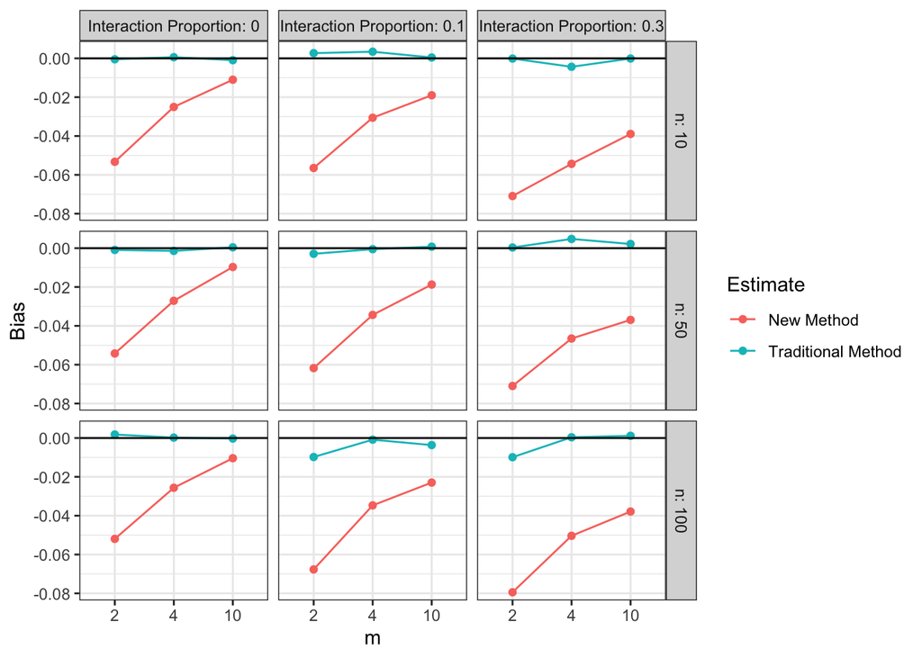

```r
sim_results2 <- read_csv("sim_results.csv")
sim_results2 %>%
  pivot_longer(cols = c(d1, v1, d2, v2), names_to = "estimate", values_to = "value") %>%
  filter(estimate != "v1" & estimate != "v2") %>%
  mutate(`Interaction Proportion` = var_inter, n = k_count, j_count = factor(j_count)) %>%
  ggplot(aes(x = j_count, y = (value - 0.4), color = estimate, group = estimate)) + geom_point() +
  geom_line() + facet_grid(n ~ `Interaction Proportion`, labeller = label_both) +
  theme_bw() + geom_hline(yintercept = 0) + xlab("m") + ylab("Bias") + labs(color = "Estimate") +
  scale_color_discrete(labels = c("New Method", "Traditional Method"))
```

### Effect Size Bias Code V2 (10000 reps)

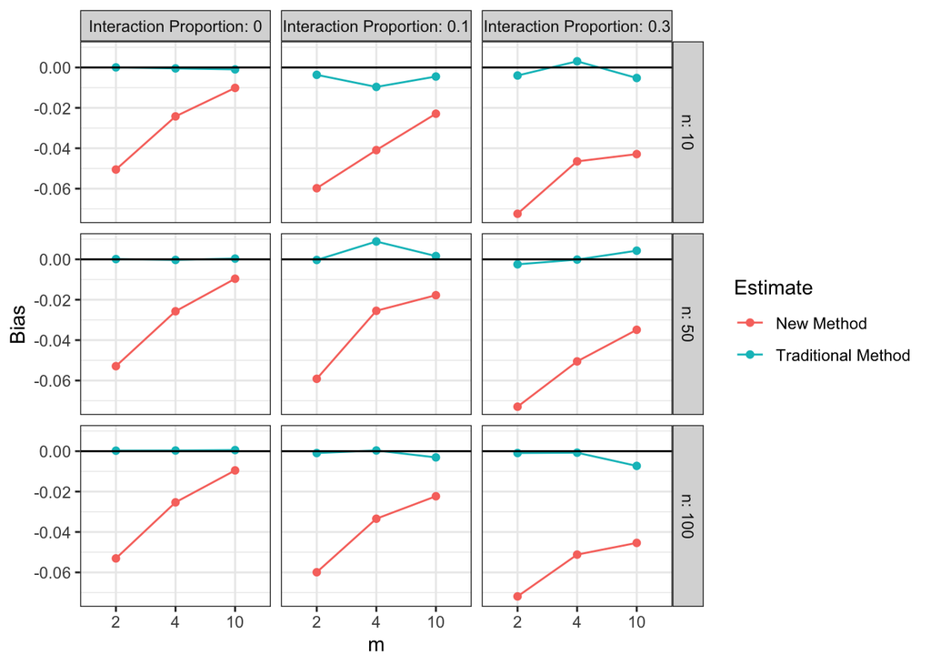

```r
sim_resultskarina <- read_csv("karinacoderesults.csv")

sim_resultskarina %>% group_by(m, n, var_inter) %>%
  summarise_at(vars(d1, v1, d2, v2, empir_var), mean) %>%
  pivot_longer(cols = c(d1, v1, d2, v2), names_to = "estimate", values_to = "value") %>%
  filter(estimate != "v1" & estimate != "v2") %>%
  mutate(`Interaction Proportion` = var_inter, n = n, m = factor(m)) %>%
  ggplot(aes(x = m, y = (value - 0.4), color = estimate, group = estimate)) + geom_point() +
  geom_line() + facet_grid(n ~ `Interaction Proportion`, labeller = label_both) +
  theme_bw() + geom_hline(yintercept = 0) + xlab("m") + ylab("Bias") + labs(color = "Estimate") +
  scale_color_discrete(labels = c("New Method", "Traditional Method"))
```

### take three

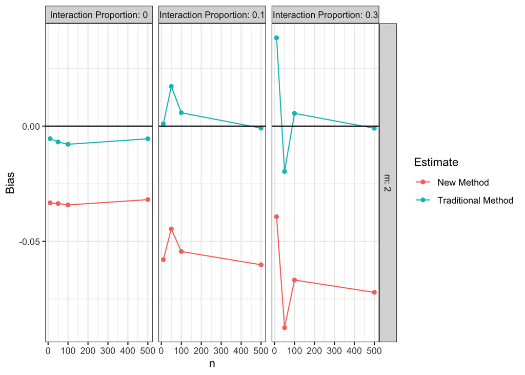

```r
sim_resultsdec16 <- read_csv("sim_results_updated_dec16.csv")
sim_resultsdec16 %>%
  group_by(n, var_inter, m) %>%
  summarise_at(vars(d1, v1, d2, v2), mean) %>%
  pivot_longer(cols = c(d1, v1, d2, v2), names_to = "estimate", values_to = "value") %>%
  filter(estimate != "v1" & estimate != "v2") %>%
  mutate(`Interaction Proportion` = var_inter, n = n, m = factor(m)) %>%
  ggplot(aes(x = n, y = (value - 0.4), color = estimate, group = estimate)) + geom_point() +
  geom_line() + facet_grid(m ~ `Interaction Proportion`, labeller = label_both) +
  theme_bw() + geom_hline(yintercept = 0) + xlab("n") + ylab("Bias") + labs(color = "Estimate") +
  scale_color_discrete(labels = c("New Method", "Traditional Method"))
```

### Variance Ratios Code V1 (1000 reps)

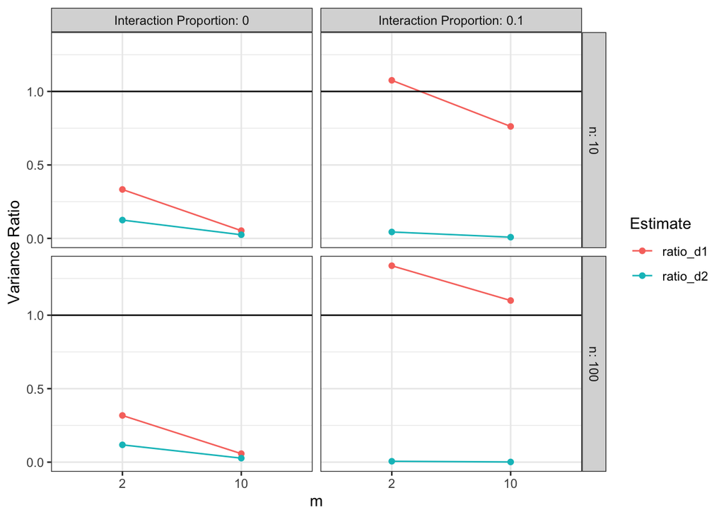

```r
sim_results3 <- read_csv("sim_results_1000reps_store_all.csv")
sim_results3 %>%
  group_by(m, n, var_inter, var_block) %>%
  summarise_at(c("d1", "d2"), var) %>%
  mutate(actual_var_d1 = d1, actual_var_d2 = d2) %>%
  select(-c(d1, d2)) %>%
  cbind( (sim_results3 %>% group_by(m, n, var_inter, var_block) %>% summarise_at(c("v1", "v2"), mean) %>% ungroup() %>% select(v1, v2))) %>%
  mutate(ratio_d1 = v1/actual_var_d1,
         ratio_d2 = v2/actual_var_d2) %>%
  pivot_longer(cols = c(ratio_d1, ratio_d2), names_to = "estimate", values_to = "value") %>%
  filter(var_block != 0) %>%
  mutate(`Interaction Proportion` = var_inter, m = factor(m)) %>%
  ggplot(aes(x = m, y = value, color = estimate, group = estimate)) + geom_point() +
  geom_line() + facet_grid(n ~ `Interaction Proportion`, labeller = label_both) +
  theme_bw() + xlab("m") + ylab("Variance Ratio") + labs(color = "Estimate") +
  scale_color_discrete() + geom_hline(yintercept = 1)
```

### Variance Ratios Code V2 (10000 reps)

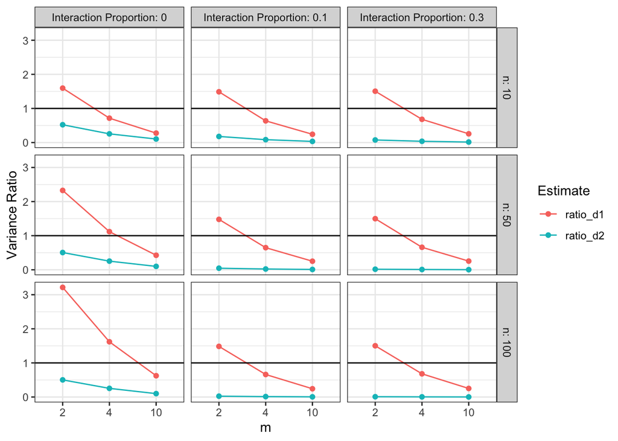

```r
empir_var <- sim_resultskarina %>% group_by(m, n, var_inter) %>%  summarise_at(c("d1", "d2"), var) %>% ungroup() %>% mutate(actual_var_d1 = d1, actual_var_d2 = d2) %>% select(-c(d1, d2, m, n, var_inter))

sim_resultskarina %>% group_by(m, n, var_inter) %>%
  select(-c(d1, d2)) %>%
  summarise_at(vars(v1, v2), mean) %>%
  cbind(empir_var) %>%
  mutate(ratio_d1 = v1/actual_var_d1,
         ratio_d2 = v2/actual_var_d2) %>%
  pivot_longer(cols = c(ratio_d1, ratio_d2), names_to = "estimate", values_to = "value") %>%
  mutate(`Interaction Proportion` = var_inter, m = factor(m)) %>%
  ggplot(aes(x = m, y = value, color = estimate, group = estimate)) + geom_point() +
  geom_line() + facet_grid(n ~ `Interaction Proportion`, labeller = label_both) +
  theme_bw() + xlab("m") + ylab("Variance Ratio") + labs(color = "Estimate") +
  scale_color_discrete() + geom_hline(yintercept = 1)
```

### take three

```r
sim_results_10 <- read_csv("sim_results_updated_dec16.csv")
```

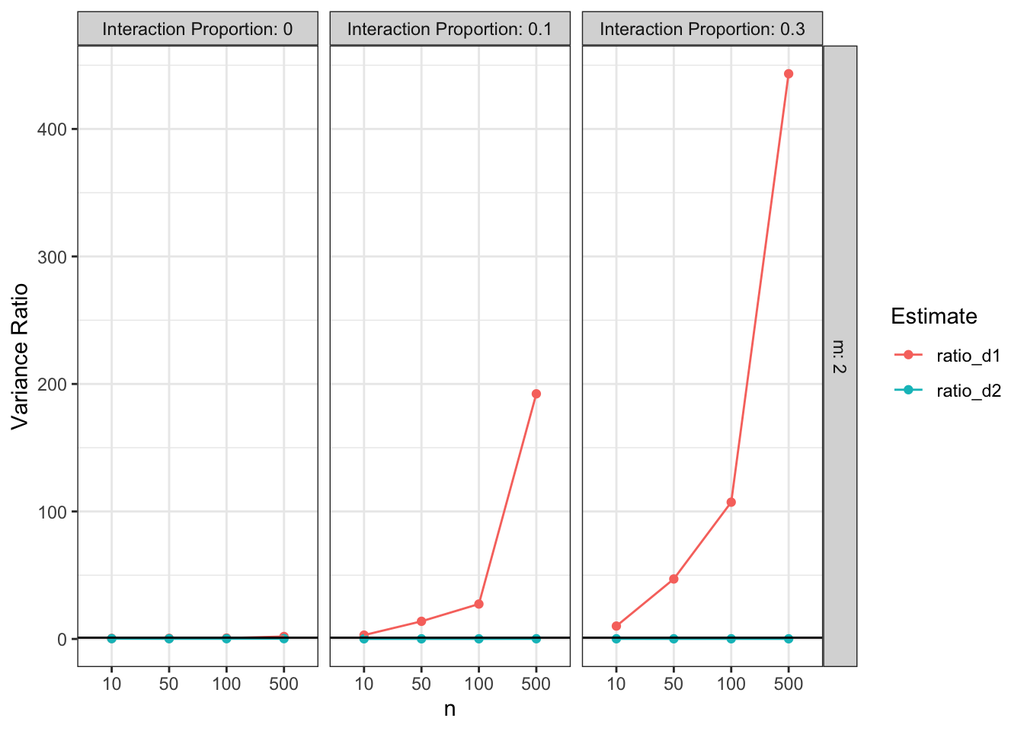

```r
sim_results_10 %>%
  group_by(m, n, var_inter) %>%
  summarise_at(c("d1", "d2"), var) %>%
  mutate(actual_var_d1 = d1, actual_var_d2 = d2) %>%
  select(-c(d1, d2)) %>%
  cbind( (sim_results_10 %>% group_by(m, n, var_inter) %>% summarise_at(c("v1", "v2"), mean) %>% ungroup() %>% select(v1, v2))) %>%
  mutate(ratio_d1 = v1/actual_var_d1,
         ratio_d2 = v2/actual_var_d2) %>%
  pivot_longer(cols = c(ratio_d1, ratio_d2), names_to = "estimate", values_to = "value") %>%
  # filter(var_block != 0) %>%
  mutate(`Interaction Proportion` = var_inter, n = factor(n)) %>%
  ggplot(aes(x = n, y = value, color = estimate, group = estimate)) + geom_point() +
  geom_line() + facet_grid(m ~ `Interaction Proportion`, labeller = label_both) +
  theme_bw() + xlab("n") + ylab("Variance Ratio") + labs(color = "Estimate") +
  scale_color_discrete() + geom_hline(yintercept = 1)
```

[output not shown]